# Ford Go Bike System Data

## Introduction

> This document explores a dataset containing information about individual rides made in a bike-sharing system covering the greater San Francisco Bay area.

## Preliminary Wrangling

```python
# import all packages and set plots to be embedded inline
import numpy as np
import pandas as pd
import matplotlib.pyplot as plt
import seaborn as sb

%matplotlib inline
```

```python
# load in the dataset into a pandas dataframe
gobike = pd.read_csv('201902-fordgobike-tripdata.csv')
gobike.head()
```

|  | duration_sec | start_time | end_time | start_station_id | start_station_name | start_station_latitude | start_station_longitude | end_station_id | end_station_name | end_station_latitude | end_station_longitude | bike_id | user_type | member_birth_year | member_gender | bike_share_for_all_trip |
| --- | --- | --- | --- | --- | --- | --- | --- | --- | --- | --- | --- | --- | --- | --- | --- | --- |
| 0 | 52185 | 2019-02-28 17:32:10.1450 | 2019-03-01 08:01:55.9750 | 21.0 | Montgomery St BART Station (Market St at 2nd St) | 37.789625 | -122.400811 | 13.0 | Commercial St at Montgomery St | 37.794231 | -122.402923 | 4902 | Customer | 1984.0 | Male | No |
| 1 | 42521 | 2019-02-28 18:53:21.7890 | 2019-03-01 06:42:03.0560 | 23.0 | The Embarcadero at Steuart St | 37.791464 | -122.391034 | 81.0 | Berry St at 4th St | 37.775880 | -122.393170 | 2535 | Customer | NaN | NaN | No |
| 2 | 61854 | 2019-02-28 12:13:13.2180 | 2019-03-01 05:24:08.1460 | 86.0 | Market St at Dolores St | 37.769305 | -122.426826 | 3.0 | Powell St BART Station (Market St at 4th St) | 37.786375 | -122.404904 | 5905 | Customer | 1972.0 | Male | No |
| 3 | 36490 | 2019-02-28 17:54:26.0100 | 2019-03-01 04:02:36.8420 | 375.0 | Grove St at Masonic Ave | 37.774836 | -122.446546 | 70.0 | Central Ave at Fell St | 37.773311 | -122.444293 | 6638 | Subscriber | 1989.0 | Other | No |
| 4 | 1585 | 2019-02-28 23:54:18.5490 | 2019-03-01 00:20:44.0740 | 7.0 | Frank H Ogawa Plaza | 37.804562 | -122.271738 | 222.0 | 10th Ave at E 15th St | 37.792714 | -122.248780 | 4898 | Subscriber | 1974.0 | Male | Yes |

```python
gobike.shape
```

```
(183412, 16)
```

```python
gobike.info()
```

```
<class 'pandas.core.frame.DataFrame'>
RangeIndex: 183412 entries, 0 to 183411
Data columns (total 16 columns):
duration_sec               183412 non-null int64
start_time                 183412 non-null object
end_time                   183412 non-null object
start_station_id           183215 non-null float64
start_station_name         183215 non-null object
start_station_latitude     183412 non-null float64
start_station_longitude    183412 non-null float64
end_station_id             183215 non-null float64
end_station_name           183215 non-null object
end_station_latitude       183412 non-null float64
end_station_longitude      183412 non-null float64
bike_id                    183412 non-null int64
user_type                  183412 non-null object
member_birth_year          175147 non-null float64
member_gender              175147 non-null object
bike_share_for_all_trip    183412 non-null object
dtypes: float64(7), int64(2), object(7)
memory usage: 22.4+ MB
```

```python
gobike.dtypes
```

```
duration_sec                 int64
start_time                  object
end_time                    object
start_station_id           float64
start_station_name          object
start_station_latitude     float64
start_station_longitude    float64
end_station_id             float64
end_station_name            object
end_station_latitude       float64
end_station_longitude      float64
bike_id                      int64
user_type                   object
member_birth_year          float64
member_gender               object
bike_share_for_all_trip     object
dtype: object
```

```python
# Check the values in each columns
print(gobike.nunique())
```

```
duration_sec                 4752
start_time                 183401
end_time                   183397
start_station_id              329
start_station_name            329
start_station_latitude        334
start_station_longitude       335
end_station_id                329
end_station_name              329
end_station_latitude          335
end_station_longitude         335
bike_id                      4646
user_type                       2
member_birth_year              75
member_gender                   3
bike_share_for_all_trip         2
dtype: int64
```

```python
# check for null values
gobike.isnull().sum()
```

```
duration_sec                  0
start_time                    0
end_time                      0
start_station_id            197
start_station_name          197
start_station_latitude        0
start_station_longitude       0
end_station_id              197
end_station_name            197
end_station_latitude          0
end_station_longitude         0
bike_id                       0
user_type                     0
member_birth_year          8265
member_gender              8265
bike_share_for_all_trip       0
dtype: int64
```

```python
# check for null values (%)
gobike.isnull().sum()/gobike.shape[0]*100
```

```
duration_sec               0.000000
start_time                 0.000000
end_time                   0.000000
start_station_id           0.107408
start_station_name         0.107408
start_station_latitude     0.000000
start_station_longitude    0.000000
end_station_id             0.107408
end_station_name           0.107408
end_station_latitude       0.000000
end_station_longitude      0.000000
bike_id                    0.000000
user_type                  0.000000
member_birth_year          4.506248
member_gender              4.506248
bike_share_for_all_trip    0.000000
dtype: float64
```

# Data Cleaning

### Issue 1: Missing values in start_station_id, start_station_name, end_station_id , end_station_name, member_birth_year, member_gender columns

### Define: Drop the rows with missing values

#### Code:

```python
gobike.dropna(inplace=True)
```

#### Test:

```python
gobike.isnull().any().sum()
```

```
0
```

### Issue 2: bike_id in string (object)

### Define: Convert the column to string(object)

#### Code:

```python
gobike['bike_id'] = gobike.bike_id.astype(str)
```

#### Test:

```python
type(gobike['bike_id'][0])
```

```
str
```

### Issue 3: start_time and end_time columns are in string (object)

### Define: Convert the columns to datetime

#### Code:

```python
gobike['start_time'] = pd.to_datetime(gobike['start_time'])
gobike['end_time'] = pd.to_datetime(gobike['end_time'])
```

#### Test:

```python
gobike['end_time'][0]
```

```
Timestamp('2019-03-01 08:01:55.975000')
```

## Data Exploration

Extracting the day, month and year colunns fron the start and end date

```python
import datetime as dt
gobike['start_day'] = gobike['start_time'].dt.day_name()
gobike['start_month'] = gobike['start_time'].dt.month_name()

# bike['start_year'] = bike['start_time'].dt.year
gobike['start_hr'] = gobike['start_time'].dt.hour
gobike['start_hr'] = gobike.start_hr.astype(str)


gobike['end_day'] = gobike['end_time'].dt.day_name()
gobike['end_month'] = gobike['end_time'].dt.month_name()
gobike['end_hr'] = gobike['end_time'].dt.hour
gobike['end_hr'] = gobike.end_hr.astype(str)

# bike['start_year'] = bike['start_time'].dt.year
gobike.head(3)
```

|  | duration_sec | start_time | end_time | start_station_id | start_station_name | start_station_latitude | start_station_longitude | end_station_id | end_station_name | end_station_latitude | ... | user_type | member_birth_year | member_gender | bike_share_for_all_trip | start_day | start_month | start_hr | end_day | end_month | end_hr |
| --- | --- | --- | --- | --- | --- | --- | --- | --- | --- | --- | --- | --- | --- | --- | --- | --- | --- | --- | --- | --- | --- |
| 0 | 52185 | 2019-02-28 17:32:10.145 | 2019-03-01 08:01:55.975 | 21.0 | Montgomery St BART Station (Market St at 2nd St) | 37.789625 | -122.400811 | 13.0 | Commercial St at Montgomery St | 37.794231 | ... | Customer | 1984.0 | Male | No | Thursday | February | 17 | Friday | March | 8 |
| 2 | 61854 | 2019-02-28 12:13:13.218 | 2019-03-01 05:24:08.146 | 86.0 | Market St at Dolores St | 37.769305 | -122.426826 | 3.0 | Powell St BART Station (Market St at 4th St) | 37.786375 | ... | Customer | 1972.0 | Male | No | Thursday | February | 12 | Friday | March | 5 |
| 3 | 36490 | 2019-02-28 17:54:26.010 | 2019-03-01 04:02:36.842 | 375.0 | Grove St at Masonic Ave | 37.774836 | -122.446546 | 70.0 | Central Ave at Fell St | 37.773311 | ... | Subscriber | 1989.0 | Other | No | Thursday | February | 17 | Friday | March | 4 |

3 rows × 22 columns

```python
# descriptive for the duration_sec
gobike.duration_sec.describe()
```

```
count    174952.000000
mean        704.002744
std        1642.204905
min          61.000000
25%         323.000000
50%         510.000000
75%         789.000000
max       84548.000000
Name: duration_sec, dtype: float64
```

```python
gobike.shape
```

```
(174952, 22)
```

### What is the structure of your dataset?

> There were initially 183,412 rides in the dataset with 16 features which was later dropped to 174952 rides and 22 features after data cleaning. There are 2 datetime, 7 float, 1 int and 12 categorical(string) variables with no particular order.

### What features in the dataset do you think will help support your investigation into your feature(s) of interest?

> I believe the member birty year, the member gender and the start_date, variable will provide me the information needed for this findings.

## Univariate Exploration

### What is the average trip duration?

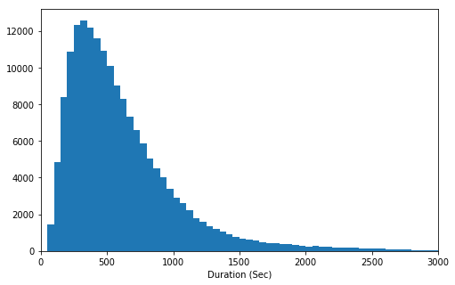

```python
# starting with a standard-scaled plot
binsize = 50
bins = np.arange(50, gobike['duration_sec'].max()+binsize, binsize)

plt.figure(figsize=[8, 5])
plt.hist(data = gobike, x = 'duration_sec', bins=bins)
plt.xlabel('Duration (Sec)')
plt.xlim([0, 3000]);
```

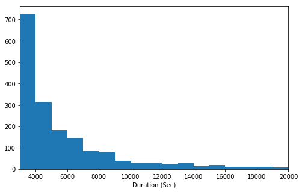

```python
# the tail part of the distribution
binsize = 1000
bins = np.arange(3000, gobike['duration_sec'].max() + binsize, binsize)

plt.figure(figsize=[8, 5])
plt.hist(data = gobike, x = 'duration_sec', bins=bins)
plt.xlabel('Duration (Sec)')
plt.xlim([3000, 20000]);
```

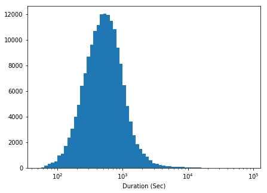

```python
# using a log scale because of the long tail of distribution
log_binsize = 0.05
bins = 10 ** np.arange(1.7, np.log10(gobike['duration_sec'].max()) + log_binsize, log_binsize)

plt.figure(figsize = [7, 5])
plt.hist(data = gobike, x = 'duration_sec', bins = bins)
plt.xscale('log')

plt.xlabel('Duration (Sec)');
```

There are many trips with small durations (200–1000 seconds) and few with long durations, which has a long-tailed distribution. It peaks at about 500 seconds and falls smoothly until about 10000 seconds. There are fewer longer intervals with breaks following that.

### Visualization for the amount of trips taken per week

```python
# convert the days and hours into orderly categorical types
ordinal_var_dict = {'start_day': ['Monday','Tuesday','Wednesday','Thursday','Friday', 'Saturday', 'Sunday'],
                    'end_day': ['Monday','Tuesday','Wednesday','Thursday','Friday', 'Saturday', 'Sunday'],
                   'start_hr': [str(i) for i in range(0,24)],
                   'end_hr': [str(i) for i in range(0,24)]}

for var in ordinal_var_dict:
    ordered_var = pd.api.types.CategoricalDtype(ordered = True,
                                                categories = ordinal_var_dict[var])
    gobike[var] = gobike[var].astype(ordered_var)
```

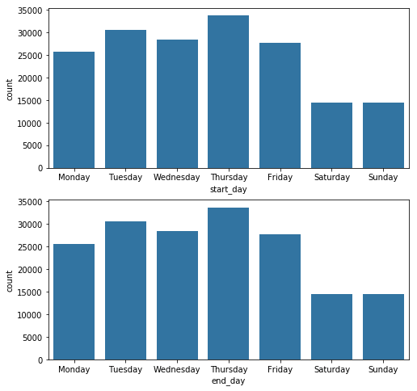

```python
# frequency of rides per day
fig, ax = plt.subplots(2, figsize = [8,8])

# Using default colour to make the visualisation easy to read
d_colour = sb.color_palette()[0]

# Plotting for the visualisations for the start days
sb.countplot(data = gobike, color = d_colour, x = 'start_day',  ax = ax[0])

# Plotting for the visualisations for the end days
sb.countplot(data = gobike, color = d_colour, x = 'end_day',  ax = ax[1]);
```

Sundays and weekends have the fewest trips recorded.

### Visualization for the amount of trips taken per hour

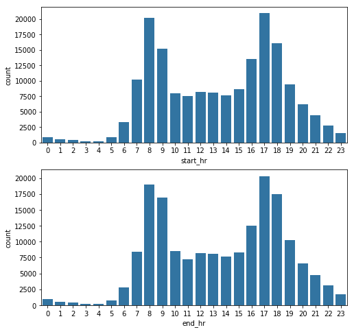

```python
fig, ax = plt.subplots(2,figsize = [8,8])

# Plotting the chart for the start hour visualisazion
sb.countplot(data = gobike, x = 'start_hr', color = d_colour,  ax = ax[0])

# Plotting the chart for the end hour visualisazion
sb.countplot(data = gobike, x = 'end_hr', color = d_colour, ax = ax[1]);
```

The 8th, 9th, 17th, and 18th hours have the greatest trip records for the days as observed. This can be attributed to morning rush hour and the end of the workday, so it is to be expected.

The lowest trip records are in the third and fourth hours.

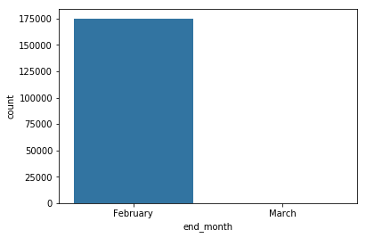

```python
# frequency of trips ended per day

sb.countplot(x = gobike['end_month'],
                   order = gobike['end_month'].value_counts(ascending=False).index);

abs_values = gobike['end_month'].value_counts(ascending=False)
rel_values = gobike['end_month'].value_counts(ascending=False, normalize=True).values * 100
labels = [f'{p[0]} ({p[1]:.3f}%)' for p in zip(abs_values, rel_values)]
labels;
# ax.bar_label(container=ax.containers[0]
```

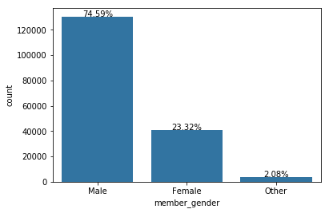

```python
# frequency of rides per gender
gen_bike = gobike.member_gender.value_counts().index
rfg = sb.countplot(data = gobike, x = 'member_gender',  color=sb.color_palette()[0], order = gen_bike)

total = len(gobike)
for p in rfg.patches:
    percentage = '{:.2f}%'.format(100 * p.get_height()/total)
    x = p.get_x() + p.get_width()/2
    y = p.get_height()+.05
    rfg.annotate(percentage, (x, y),ha='center')
plt.show();
```

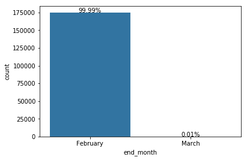

```python
# amount of trips ended per day including the percentages
bike_value = gobike.end_month.value_counts().index
efd = sb.countplot(data = gobike, x = 'end_month',  color = d_colour, order = bike_value)

total = len(gobike)
for p in efd.patches:
    percentage = '{:.2f}%'.format(100 * p.get_height()/total)
    x = p.get_x() + p.get_width()/2
    y = p.get_height()+.05
    efd.annotate(percentage, (x, y),ha='center')
plt.show();
```

With the exception of a very small number (14) that finished in March, all of the journeys began and ended in February.

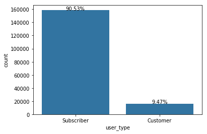

```python
# frequency fo rides per user type
ut_bike = gobike.user_type.value_counts().index
rf_ut = sb.countplot(data = gobike, x = 'user_type',  color = d_colour, order = ut_bike)

total = len(gobike)
for p in rf_ut.patches:
    percentage = '{:.2f}%'.format(100 * p.get_height()/total)
    x = p.get_x() + p.get_width()/2
    y = p.get_height()+.05
    rf_ut.annotate(percentage, (x, y),ha='center')
plt.show();
```

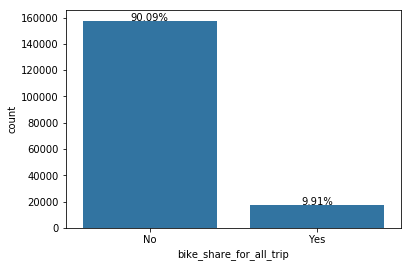

```python
# frequency of rides per bike_share_for_all_trip
bfat = gobike.bike_share_for_all_trip.value_counts().index
bs = sb.countplot(data = gobike, x = 'bike_share_for_all_trip',  color = d_colour, order = bfat)

total = len(gobike)
for p in bs.patches:
    percentage = '{:.2f}%'.format(100 * p.get_height()/total)
    x = p.get_x() + p.get_width()/2
    y = p.get_height()+.05
    bs.annotate(percentage, (x, y),ha='center')
plt.show();
```

## Bivariate Exploration

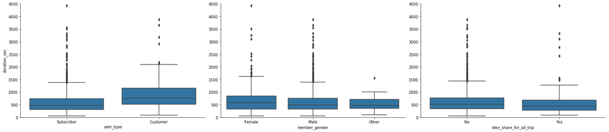

```python
# plot matrix of numeric features against categorical features.
# can use a larger sample since there are fewer plots and they're simpler in nature.
samples = np.random.choice(gobike.shape[0], 2000, replace = False)
my_samp = gobike.loc[samples,:]

def boxgrid(x, y, **kwargs):
    """ Quick hack for creating box plots with seaborn's PairGrid. """
    sb.boxplot(x, y, color = d_colour)

plt.figure(figsize = [15, 15])
a = sb.PairGrid(data = my_samp, y_vars = 'duration_sec', x_vars = ['user_type', 'member_gender',
                                                                 'bike_share_for_all_trip'], size = 5, aspect = 1.5);
a.map(boxgrid)
plt.ylim([0,4500])
plt.show();
```

Customers seem to spend more time overall compared to subscribers, and women seem to spend more time overall than men.

On average, bike share for all sorts of trips is comparable.

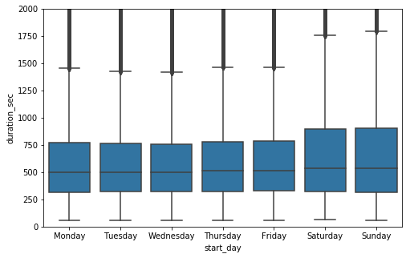

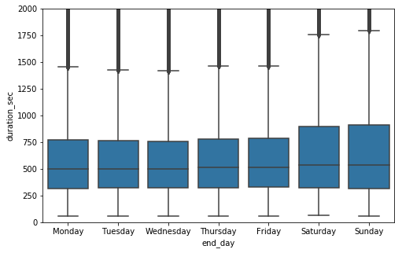

```python
def boxplot(x, y, **kwargs):
    sb.boxplot(x, y, color = d_colour)

plt.figure(figsize = [8, 5])
sns.boxplot(data = gobike, x="start_day", y="duration_sec", color = d_colour);
plt.ylim([0,2000])

plt.figure(figsize = [8, 5])
sns.boxplot(data = gobike, x="end_day", y="duration_sec", color = d_colour);
plt.ylim([0,2000])
plt.show();
```

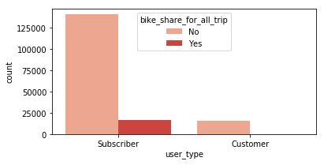

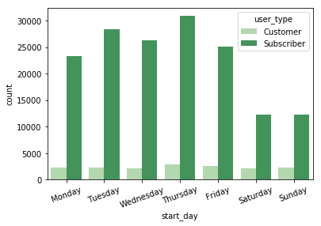

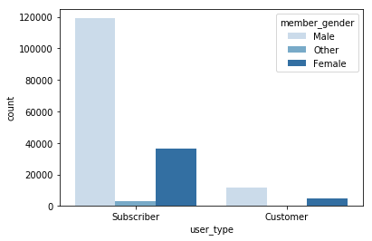

```python
# using the full data since there are only three subplots to create
plt.figure(figsize = [6, 10])
# plot 1: user_type vs bike_share_for_all_trip
plt.subplot(3, 1, 1)
sb.countplot(data = gobike, x = 'user_type', hue = 'bike_share_for_all_trip', order = ut_bike, palette = 'Reds')
plt.show()

# plot 2: end_day vs. user_type
sb.countplot(data = gobike, x = 'start_day', hue = 'user_type', palette = 'Greens')
plt.xticks(rotation = 20)
plt.show()

# plot 3: user_type vs. member_gender,
sb.countplot(data = gobike, x = 'user_type', hue = 'member_gender', order = ut_bike, palette = 'Blues')
plt.show()
```

We can infer that only subscribers have access to bike sharing, and that customer demographics have little bearing on the number of rides made on any given weekday.

## Multivariate Exploration

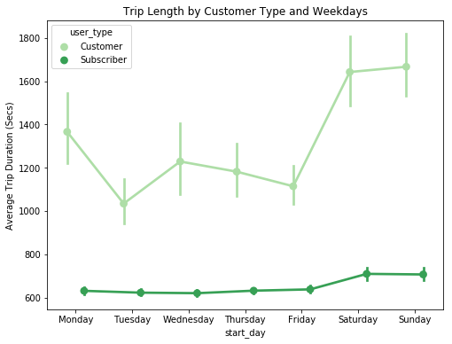

```python
fig = plt.figure(figsize = [8,6])
sb.pointplot(data = gobike, x="start_day", y = "duration_sec",  hue = 'user_type',
           palette = 'Greens', dodge = 0.3 )
plt.title('Trip Length by Customer Type and Weekdays')
plt.ylabel('Average Trip Duration (Secs)')
plt.show();
```

Subscribers often travel short distances with slight increases on weekends, but not nearly as far as consumers do, regardless of the day of the week (the biggest distances are on weekends).

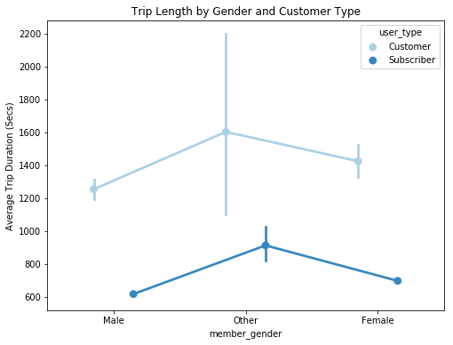

```python
fig = plt.figure(figsize = [8,6])
sb.pointplot(data = gobike, x = "member_gender", y = "duration_sec",  hue = 'user_type',
           palette = 'Blues', dodge = 0.3 )
plt.title('Trip Length by Gender and Customer Type')
plt.ylabel('Average Trip Duration (Secs)')
plt.show();
```

The other gender group spent the greatest time among subscribers and consumers, followed by women and then men.

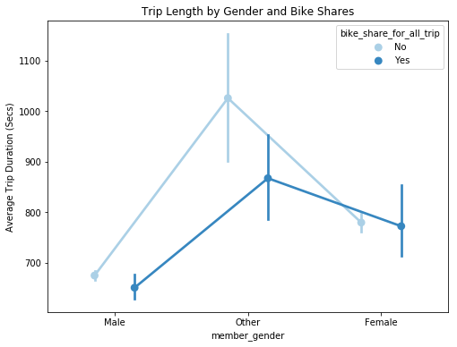

```python
import seaborn as sns

fig = plt.figure(figsize = [8,6])
sb.pointplot(data = gobike, x = "member_gender", y = "duration_sec",  hue = 'bike_share_for_all_trip',
           palette = 'Blues', dodge = 0.3 )
plt.title('Trip Length by Gender and Bike Shares')
plt.ylabel('Average Trip Duration (Secs)')
plt.show();
```